# RPT: Supplementary

12 May, 2025

## Bearing calculations

As part of the spatial repeatability analyses, I comparing birds’ bearings during their foraging trips within and between individuals, and within and between seasons.

Originally I computed the bearings as the bearing between the distal point on a bird’s foraging trip to the colony. However, this can lead to small but important perturbations - for example the distal point might represent a short section of the foraging track that deviates substantially from the rest of the track.

To test for the importance of this, and to determine the most appropriate bearing measure, I calculated three options for birds’ bearings:

- Distal bearing - the bearing between the distal point and the colony
- Average bearing - the average bearing on birds’ foraging trips
- Average foraging bearing - the average bearing for sections of birds’ trips marked as ‘foraging’

Below I summarise the results. Overall, the choice of bearing did not change the results substantially. I settled on the average bearing, as this is more defensible and easier to explain.

### Plot of bearing differences for each metric

For most of the species/colony combinations, which metric is used makes little difference to the overall results. The exception is for WAAL at Bird Island, which seem to be a bit of a mess regardless of the metric used. Possibly this is because I have few repeats for this population, or they are simply not very consistent by any measure. Based on these results, intepretation, and interpretability, I settled on the *average bearing* measure.

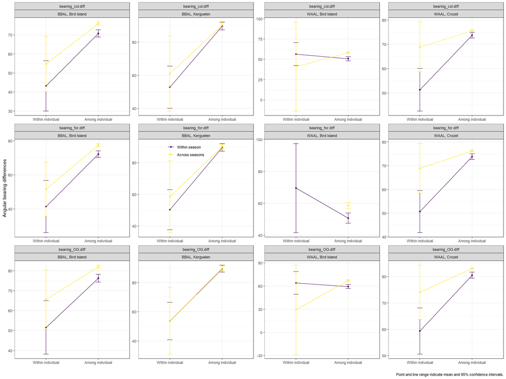